# Задание 8.1.

На основании учебных данных о параметрах вина (sklearn.datasets.load_wine) необходимо классифицировать напиток со следующим параметрами: alcohol – 4.25; malic acid – 1.68; ash – 2.51; alcalinity of ash – 15.3; magnesium – 125.0; total phenols – 2.70; flavanoids – 3.02; nonflavanoid phenols – 0.25; proanthocyanins – 2.27; color intensity –5.61; hue – 1.08; od280/od315 of diluted wines –3.82; proline –1065.0.

```python
from sklearn.datasets import load_wine
X, y = load_wine(return_X_y=True)

import pandas as pd

load_wine = load_wine()
df_wine = pd.DataFrame(load_wine.data,columns=load_wine.feature_names)
df_wine['target'] = pd.Series(load_wine.target)
from sklearn.linear_model import PassiveAggressiveClassifier
classifier =  PassiveAggressiveClassifier()
classifier.fit(load_wine.data, load_wine.target)
X_pred = pd.DataFrame([[4.25, 1.68, 2.51, 15.3, 125.0, 2.70, 3.02, 0.25, 2.27, 5.61, 1.08, 3.82, 1065.0 ]])
y_pred = classifier.predict(X_pred)
print(y_pred)
```

```
[0]
```

# Задание 8.2

На основании набора данных, полученного при решении зада-ния 6, приведенного в теме 11, проведите исследование и сравни-тельные эксперименты для следующих методов построения моделей линейной классификации (по вариантам): 6) использующим персептроны

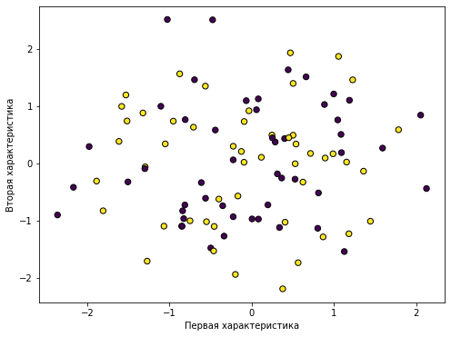

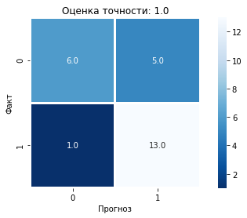

```
Отчет по итогу проведенной классификации:
              precision    recall  f1-score   support

           0       0.86      0.55      0.67        11
           1       0.72      0.93      0.81        14

    accuracy                           0.76        25
   macro avg       0.79      0.74      0.74        25
weighted avg       0.78      0.76      0.75        25
```

```python
from sklearn.datasets import make_classification
from sklearn.model_selection import train_test_split
from sklearn.metrics import mean_squared_error, r2_score
import matplotlib.pyplot as plt
import numpy as np
# получение данных
X, y = make_classification(n_features=600, n_redundant=12, n_informative=5,
                             n_clusters_per_class=3)

# разбиение набора данных на тренировочный и тестовый
from sklearn.model_selection import train_test_split

X_train, X_test, y_train, y_test = train_test_split(X, y, random_state=0)

# обучение модели и прогнозирование

from sklearn.linear_model import PassiveAggressiveClassifier
classifier =  PassiveAggressiveClassifier( C=0.2, max_iter=3000, fit_intercept=True,random_state=1, average=False, tol=None)


classifier.fit(X_train, y_train)
y_pred = classifier.predict(X_test)

 # визуализация модели
plt.figure(figsize=(8,6))
plt.xlabel("Первая характеристика")
plt.ylabel("Вторая характеристика")
plt.scatter(X[:, 0], X[:, 1], marker='o', c=y, s=40, edgecolor='k')

# вывод матрицы ошибок модели
# краткая форма - print (confusion_matrix(y_test, y_pred))
from sklearn.metrics import confusion_matrix
import seaborn as sns
cm = confusion_matrix(y_test, y_pred)
plt.figure(figsize=(8,4))
sns.heatmap(cm, annot=True, fmt=".1f", linewidths=1.9, square = True,
            cmap = 'Blues_r');
plt.ylabel('Факт');
plt.xlabel('Прогноз');
score=classifier.score(X_train, y_train)
all_sample_title = 'Оценка точности: {0}'.format(score)
plt.title(all_sample_title, size = 12);
plt.show();

# вывод отчета по итогу проведенной классификациии
print ('Отчет по итогу проведенной классификации:')
from sklearn.metrics import classification_report
print(classification_report(y_test, y_pred))
```

# Задание 8.3

На основании набора данных, полученного при решении зада-ния 6, приведенного в теме 8, проведите исследование и сравнитель-ные эксперименты для следующих методов построения моделей не-линейной классификации (по вариантам): 5) наив-ный байесовский метод. При проведении экспериментов использовать различные допу-стимые комбинации параметры методов. Сравните с решением зада-ния 2. Сделайте выводы.

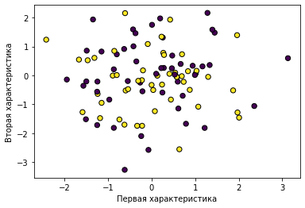

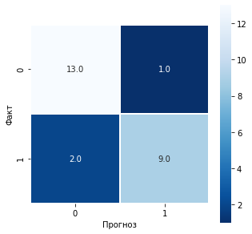

```
Отчет по итогу проведенной классификации:
              precision    recall  f1-score   support

           0       0.87      0.93      0.90        14
           1       0.90      0.82      0.86        11

    accuracy                           0.88        25
   macro avg       0.88      0.87      0.88        25
weighted avg       0.88      0.88      0.88        25
```

```python
# получение данных
X, y = make_classification(n_features=600, n_redundant=12, n_informative=5,
                             n_clusters_per_class=3)
# разбиение набора данных на тренировочный и тестовый
from sklearn.model_selection import train_test_split
X_train, X_test, y_train, y_test = train_test_split(X, y, random_state=0)

# обучение модели и прогнозирование
from sklearn.naive_bayes import GaussianNB
classifier = GaussianNB(var_smoothing =0.001)
classifier.fit(X_train, y_train)
y_pred = classifier.predict(X_test)

# визуализация модели
import numpy as np
import matplotlib.pyplot as plt
plt.xlabel("Первая характеристика")
plt.ylabel("Вторая характеристика")
plt.scatter(X[:, 0], X[:, 1], marker='o', c=y, s=40, edgecolor='k')

# вывод матрицы ошибок модели
from sklearn.metrics import confusion_matrix
import seaborn as sns
cm = confusion_matrix(y_test, y_pred)
plt.figure(figsize=(5,5))
sns.heatmap(cm, annot=True, fmt=".1f", linewidths=0.9, square = True, cmap = 'Blues_r');
plt.ylabel('Факт');
plt.xlabel('Прогноз');
score=classifier.score(X_test, y_test)
all_sample_title = 'Оценка точности: {0}'.format(score)
plt.show();

# вывод отчета по итогу проведенной классификациии
print ('Отчет по итогу проведенной классификации:')
from sklearn.metrics import classification_report
print(classification_report(y_test, y_pred))
```

# Задание 8.4

На основании данных о транзакциях по кредитным картам необходимо выявить те из них, которые являются мошенническими. Источник данных: https://www.kaggle.com/mlg-ulb/creditcardfraud В наборе данных признаки V1, V2,… V28 – это основные ком-поненты, значения которых в целях безопасности были преобразова-ны; признак «Time» содержит секунды, прошедшие между каждой транзакцией и первой транзакцией в наборе данных; признак «Amount» – это сумма транзакции; признак «Class» – принадлеж-ность транзакции к одному из двух классов (1 –мошенничество). Необходимо: 1) загрузить набор данных; 2) провести исследование данных; 3) выполнить предварительную обработку данных (при необхо-димости); 4) выбрать метод построения модели классификации (решение обосновать); 5) выбрать метрику оценки качества модели (решение обосно-вать); 6) осуществить обучение (на случайной выборке в размере 90%.) и тестирование (на случайной выборке в размере 10%.) модели классификации с использованием различных комбинаций её пара-метров; 7) оценить качество различных по параметрам вариантов моде-ли по выбранной метрике; 8) осуществить классификацию на основании варианта модели с лучшим значением метрики.

```
Случаи мошенничества: 492
Действительные транзакции: 284315
Модель Случайного леса:
accuracy 0.9995786664794073
precision 0.9722222222222222
recall 0.7608695652173914
F1-Score 0.853658536585366
Коэффициент корреляции Мэтьюза 0.8598871352080946
```

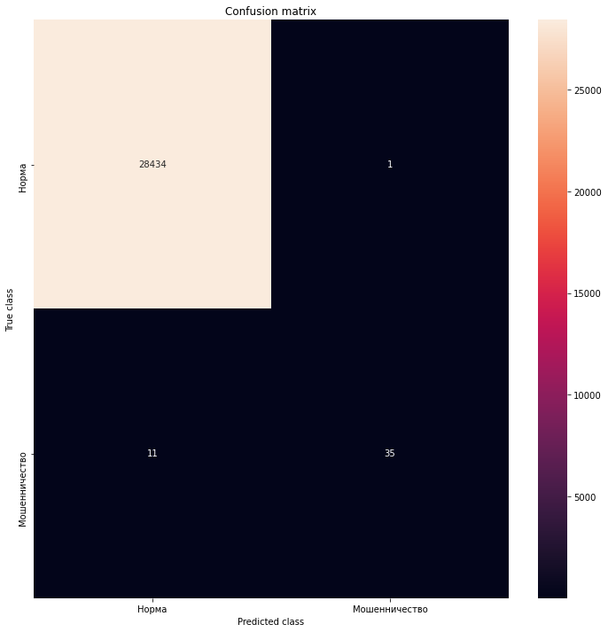

```python
from sklearn.model_selection import train_test_split
from sklearn.ensemble import RandomForestClassifier
import numpy as np
import pandas as pd
import matplotlib.pyplot as plt
import seaborn as sns
from matplotlib import gridspec

#загрузка данных

path ="D:/транзации/creditcard.csv"
data = pd.read_csv(path)


# Определяем количество случаев мошенничества в наборе данных

fraud = data[data['Class'] == 1]
valid = data[data['Class'] == 0]

print('Случаи мошенничества: {}'.format(len(data[data['Class'] == 1])))
print('Действительные транзакции: {}'.format(len(data[data['Class'] == 0])))

# разделение набора данных на Х и У

X = data.drop(['Class'], axis = 1).values
Y = data["Class"].values

# деление на тренировочную и тестовую выборку

xTrain, xTest, yTrain, yTest = train_test_split( X, Y, test_size = 0.1, random_state = 42)

#построение и тренировка модели
rfc = RandomForestClassifier()
rfc.fit(xTrain, yTrain)

#предсказание
yPred = rfc.predict(xTest)

# оценка качества моделей
from sklearn.metrics import classification_report, accuracy_score
from sklearn.metrics import precision_score, recall_score
from sklearn.metrics import f1_score, matthews_corrcoef
from sklearn.metrics import confusion_matrix



n_outliers = len(fraud)
n_errors = (yPred != yTest).sum()
print("Модель Случайного леса: ")

acc = accuracy_score(yTest, yPred)
print("accuracy {}".format(acc))

prec = precision_score(yTest, yPred)
print("precision {}".format(prec))

rec = recall_score(yTest, yPred)
print("recall {}".format(rec))

f1 = f1_score(yTest, yPred)
print("F1-Score {}".format(f1))

MCC = matthews_corrcoef(yTest, yPred)
print("Коэффициент корреляции Мэтьюза {}".format(MCC))


LABELS = ['Норма', 'Мошенничество']
conf_matrix = confusion_matrix(yTest, yPred)
plt.figure(figsize =(12, 12))
sns.heatmap(conf_matrix, xticklabels = LABELS, yticklabels = LABELS, annot = True, fmt ="d");
plt.title("Confusion matrix")
plt.ylabel('True class')
plt.xlabel('Predicted class')
plt.show()
```

# Задание 8.5

На основании данных о клиентах банка осуществите их класси-фикацию на надежных и ненадежных (задача кредитного скоринга). Источник данных: https://www.openml.org/d/31 В наборе данных присутствуют 20 признаков, характеризующих клиента банка, а также признак «Class» – принадлежность клиента банка к одному из двух классов кредитоспособности («Bad» или «Good» ). Необходимо: 1) загрузить набор данных; 2) провести исследование данных; 3) выполнить предварительную обработку данных (при необхо-димости); 4) выбрать метод построения модели классификации (решение обосновать); 5) выбрать метрику оценки качества модели (решение обосно-вать); 6) осуществить обучение (на случайной выборке в размере 90%.) и тестирование (на случайной выборке в размере 10%.) модели классификации с использованием различных комбинаций её пара-метров; 7) оценить качество различных по параметрам вариантов моде-ли по выбранной метрике; 8) осуществить классификацию на основании варианта модели с лучшим значением метрики

```
Плохие клиенты: 300
Хорошие клиенты: 700
Модель Случайного леса:
accuracy 0.8
precision 0.7647058823529411
recall 0.4482758620689655
F1-Score 0.5652173913043479
Коэффициент корреляции Мэтьюза 0.47345843098020474
```

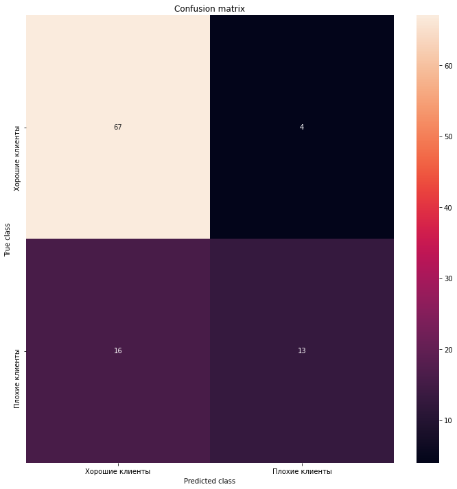

```python
#загрузка данных

path ="C:/Users/logistics/Downloads/dataset_31_credit-g (1).csv"
data = pd.read_csv(path)



data['class'] = data['class'].replace("good", 0).replace("bad", 1)


# Определяем количество плохих клиентов в наборе данных

fraud = data[data['class'] == 1]
valid = data[data['class'] == 0]

print('Плохие клиенты: {}'.format(len(data[data['class'] == 1])))
print('Хорошие клиенты: {}'.format(len(data[data['class'] == 0])))

# разделение набора данных на Х и У

X = data.drop(['class'], axis = 1).values

Y = data["class"].values


from sklearn import preprocessing

X=preprocessing.OrdinalEncoder().fit_transform(X)
# деление на тренировочную и тестовую выборку

xTrain, xTest, yTrain, yTest = train_test_split( X, Y, test_size = 0.1, random_state = 42)

#построение и тренировка модели
rfc = RandomForestClassifier()
rfc.fit(xTrain, yTrain)

#предсказание
yPred = rfc.predict(xTest)

# оценка качества моделей
from sklearn.metrics import classification_report, accuracy_score
from sklearn.metrics import precision_score, recall_score
from sklearn.metrics import f1_score, matthews_corrcoef
from sklearn.metrics import confusion_matrix



n_outliers = len(fraud)
n_errors = (yPred != yTest).sum()
print("Модель Случайного леса: ")

acc = accuracy_score(yTest, yPred)
print("accuracy {}".format(acc))

prec = precision_score(yTest, yPred)
print("precision {}".format(prec))

rec = recall_score(yTest, yPred)
print("recall {}".format(rec))

f1 = f1_score(yTest, yPred)
print("F1-Score {}".format(f1))

MCC = matthews_corrcoef(yTest, yPred)
print("Коэффициент корреляции Мэтьюза {}".format(MCC))


LABELS = ['Хорошие клиенты', 'Плохие клиенты']
conf_matrix = confusion_matrix(yTest, yPred)
plt.figure(figsize =(12, 12))
sns.heatmap(conf_matrix, xticklabels = LABELS, yticklabels = LABELS, annot = True, fmt ="d");
plt.title("Confusion matrix")
plt.ylabel('True class')
plt.xlabel('Predicted class')
plt.show()
```

# Задание 8.6

```
Train shape: (60000, 784)
Test shape: (10000, 784)
Confusion matrix, without normalization
[[ 963    0    3    1    3   28    8    0    6    4]
 [   1 1080    8    0    1   10    6    0    2    4]
 [   2    8  880    4   13   20   26    8   13    6]
 [   2    8   30  624    5  303    6   12    8   36]
 [   1    2    3    0  832   22    7    0    3  105]
 [   7    4    4    6    5  839   17    4   15   14]
 [   5    2    5    0    8   37  921    1    1    1]
 [   1    6   17    2   14   16    1  818    2  122]
 [   5   19   21    7    3  233   13    3  610   70]
 [   3    3    1    2   21   54    0   21    5  894]]
```

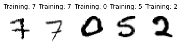

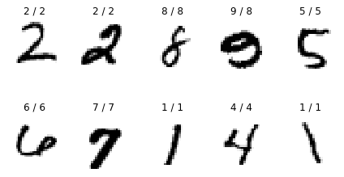

```python
def plot_confusion_matrix(y_true, y_pred, classes,
                          normalize=False,
                          title=None,
                          cmap=plt.cm.Blues):
    """
    This function prints and plots the confusion matrix.
    Normalization can be applied by setting `normalize=True`.
    """
    if not title:
        if normalize:
            title = 'Normalized confusion matrix'
        else:
            title = 'Confusion matrix, without normalization'

    # Compute confusion matrix
    cm = confusion_matrix(y_true, y_pred)
    # Only use the labels that appear in the data
    classes = classes[unique_labels(y_true, y_pred)]
    if normalize:
        cm = cm.astype('float') / cm.sum(axis=1)[:, np.newaxis]
        print("Normalized confusion matrix")
    else:
        print('Confusion matrix, without normalization')

    print(cm)

    fig, ax = plt.subplots()
    im = ax.imshow(cm, interpolation='nearest', cmap=cmap)
    ax.figure.colorbar(im, ax=ax)
    # We want to show all ticks...
    ax.set(xticks=np.arange(cm.shape[1]),
           yticks=np.arange(cm.shape[0]),
           # ... and label them with the respective list entries
           xticklabels=classes, yticklabels=classes,
           title=title,
           ylabel='True label',
           xlabel='Predicted label')

    # Rotate the tick labels and set their alignment.
    plt.setp(ax.get_xticklabels(), rotation=45, ha="right",
             rotation_mode="anchor")

    # Loop over data dimensions and create text annotations.
    fmt = '.2f' if normalize else 'd'
    thresh = cm.max() / 2.
    for i in range(cm.shape[0]):
        for j in range(cm.shape[1]):
            ax.text(j, i, format(cm[i, j], fmt),
                    ha="center", va="center",
                    color="white" if cm[i, j] > thresh else "black")
    fig.tight_layout()
    return ax

from sklearn.datasets import fetch_openml
# Загружаем данные из https://www.openml.org/d/554
path ="C:/Users/logistics/Downloads/mnist_784 (1).csv"
data = pd.read_csv(path)
X = data.drop(['class'], axis = 1).values
y = data["class"].values
#X, y = fetch_openml('mnist_784', version=1, return_X_y=True)

from sklearn.model_selection import train_test_split
X_train, X_test, y_train, y_test = train_test_split(X, y, train_size=60000, test_size=10000)
y_train = y_train.astype(int)
y_test = y_test.astype(int)
print("Train shape:", X_train.shape)
print("Test shape:", X_test.shape)

import matplotlib.pyplot as plt
for i in range(5):
    plt.subplot(2, 5, i + 1)
    plt.axis('off')
    plt.imshow(X_train[i].reshape(28,28), cmap=plt.cm.gray_r, interpolation='nearest')
    plt.title('Training: {}'.format(y_train[i]))

from sklearn import linear_model
# Создадим классификатор: метод опорных векторов
classifier = linear_model.SGDClassifier(loss='hinge',
                                        penalty='l2',
                                        alpha=0.0001,
                                        l1_ratio=0.15,
                                        fit_intercept=True,
                                        max_iter=1000,
                                        tol=0.001,
                                        shuffle=True,
                                        verbose=0,
                                        epsilon=0.1,
                                        n_jobs=None,
                                        random_state=None,
                                        learning_rate='optimal',
                                        eta0=0.0,
                                        power_t=0.5,
                                        early_stopping=False,
                                        validation_fraction=0.1,
                                        n_iter_no_change=5,
                                        class_weight=None,
                                        warm_start=False,
                                        average=False)
# Обучим классификатор
classifier.fit(X_train, y_train)


from sklearn.metrics import confusion_matrix
from sklearn.utils.multiclass import unique_labels

expected = y_test
predicted = classifier.predict(X_test)
import numpy as np
class_names = np.array(["0", "1", "2", "3", "4", "5", "6", "7", "8", "9"])
# Plot non-normalized confusion matrix
import matplotlib.pyplot as plt
plot_confusion_matrix(expected, predicted, classes=class_names,
                      title='Confusion matrix, without normalization')

for i in range(10):
    plt.subplot(2, 5, i + 1)
    plt.axis('off')
    plt.imshow(X_test[i].reshape(28,28), cmap=plt.cm.gray_r, interpolation='nearest')
    plt.title('{0} / {1}'.format(y_test[i],predicted[i]))
```

# Задание 8.7

На основании данных об эффективности телефонных предло-жений о заключении договора на банковский депозит произвести разделение новых обращений на две группы: перспективные и непер-спективные. Источник данных: https://www.openml.org/d/1461 В наборе данных присутствуют 16 признаков, характеризующих потенциального клиента банка, а также признак «Class», характери-зующий заключение контракта («Да» или «Нет» ). Необходимо: 1) загрузить набор данных и провести его исследование; 2) выполнить предварительную обработку данных (при необхо-димости); 3) выбрать метод построения модели классификации и метрику оценки качества модели (решение обосновать); 4) осуществить обучение модели классификации с использова-нием различных комбинаций её параметров (размер обучающвыбо-рок выбрать самостоятельно); 5) оценить качество различных по параметрам вариантов моде-ли по выбранной метрике. 6) осуществить классификацию на основании варианта модели с лучшим значением метрики

```
Неэффективные предложения: 5289
Эффективные предложения: 39922
Модель Случайного леса:
accuracy 0.8993808049535603
precision 0.9213240585272248
recall 0.9679939516129032
F1-Score 0.9440825857195526
Коэффициент корреляции Мэтьюза 0.4594640637243613
```

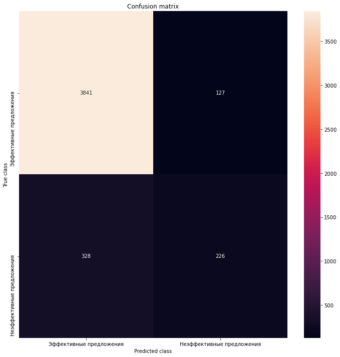

```python
path ="C:/Users/logistics/Downloads/phpkIxskf.csv"
data = pd.read_csv(path)


# Определяем количество неэффективных предложений в наборе данных

fraud = data[data['Class'] == 2]
valid = data[data['Class'] == 1]

print('Неэффективные предложения: {}'.format(len(data[data['Class'] == 2])))
print('Эффективные предложения: {}'.format(len(data[data['Class'] == 1])))

# разделение набора данных на Х и У

X = data.drop(['Class'], axis = 1).values

Y = data["Class"].values


from sklearn import preprocessing

X=preprocessing.OrdinalEncoder().fit_transform(X)
# деление на тренировочную и тестовую выборку

xTrain, xTest, yTrain, yTest = train_test_split( X, Y, test_size = 0.1, random_state = 42)

#построение и тренировка модели
rfc = RandomForestClassifier()
rfc.fit(xTrain, yTrain)

#предсказание
yPred = rfc.predict(xTest)

# оценка качества моделей
from sklearn.metrics import classification_report, accuracy_score
from sklearn.metrics import precision_score, recall_score
from sklearn.metrics import f1_score, matthews_corrcoef
from sklearn.metrics import confusion_matrix



n_outliers = len(fraud)
n_errors = (yPred != yTest).sum()
print("Модель Случайного леса: ")

acc = accuracy_score(yTest, yPred)
print("accuracy {}".format(acc))

prec = precision_score(yTest, yPred)
print("precision {}".format(prec))

rec = recall_score(yTest, yPred)
print("recall {}".format(rec))

f1 = f1_score(yTest, yPred)
print("F1-Score {}".format(f1))

MCC = matthews_corrcoef(yTest, yPred)
print("Коэффициент корреляции Мэтьюза {}".format(MCC))


LABELS = ['Эффективные предложения', 'Неэффективные предложения']
conf_matrix = confusion_matrix(yTest, yPred)
plt.figure(figsize =(12, 12))
sns.heatmap(conf_matrix, xticklabels = LABELS, yticklabels = LABELS, annot = True, fmt ="d");
plt.title("Confusion matrix")
plt.ylabel('True class')
plt.xlabel('Predicted class')
plt.show()
```